# DMRcaller preparation

### colplot

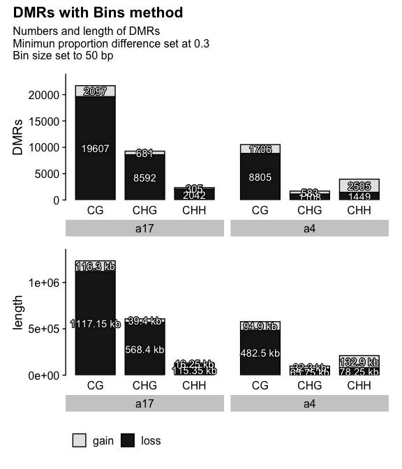

## 2.3. Replicas (bins method)

When computing DMRs using the replicas method, the algorithm uses beta regression statistical test instead of the Score/Fisher that the other methods use, which gives different statistics in the volcano plot (see how different they look to the bins method with the score test).

### by minimun proportion difference, size = 100

#### number

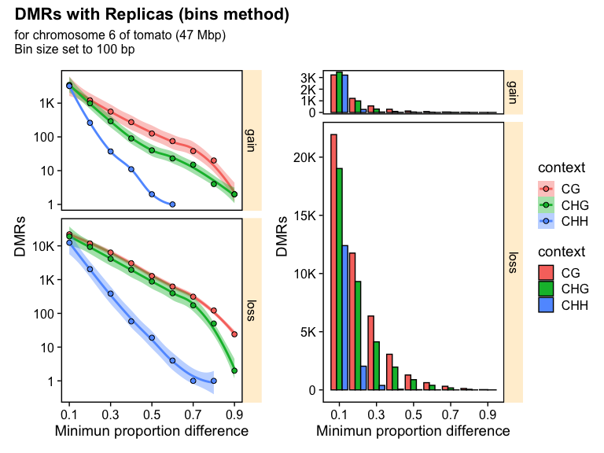

#### length

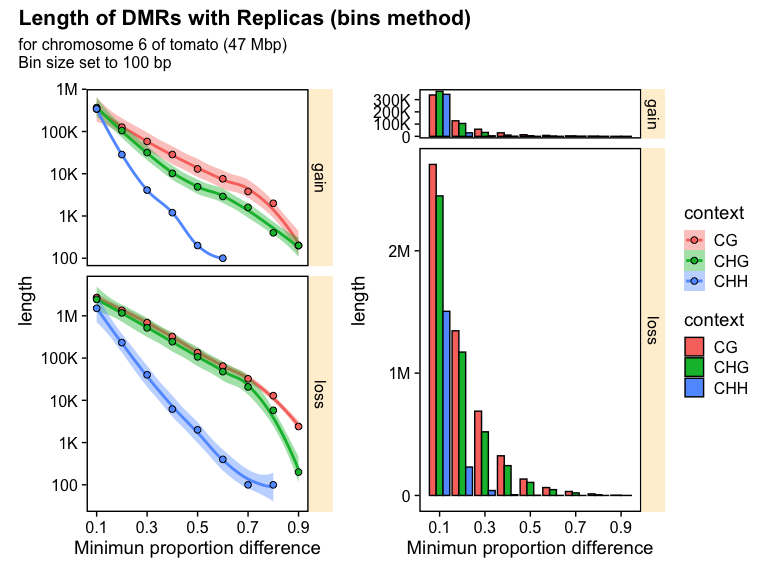

### Volcano plot

#### 100 bp, mpd = 0.1

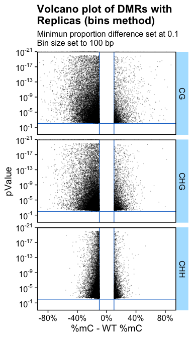

## 2.4. Neighbourhood method

The coverage after pooling the replicas maybe is enough to try the neighbourhood method to call single Differentially Methylated Cytosines. I should try that later.

Test for Neighbourhood method for:

- 2 samples: A4 & A17
- 3 contexts: CG, CHG, CHH
- 9 minimum proportion differences: 0.1, 0.2, 0.3, 0.4, 0.5, 0.6, 0.7, 0.8, 0.9
- 10 min sizes: 1, 10, 20, 50, 100, 200, 500, 1000, 2000, 5000
- 3 minimum Gap sizes: 0 (for DMCs), 200, 2x(size)

### by window size

#### number

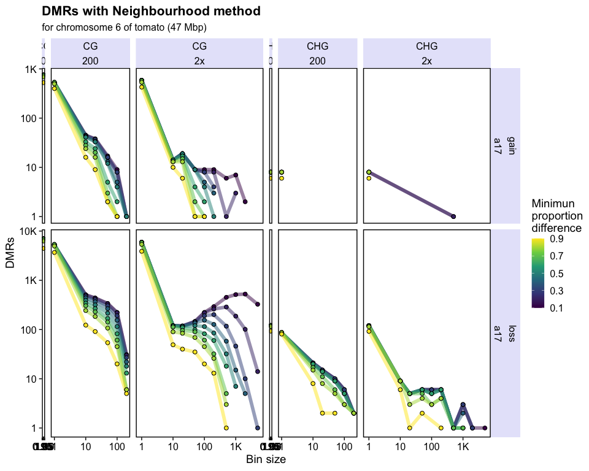

#### length

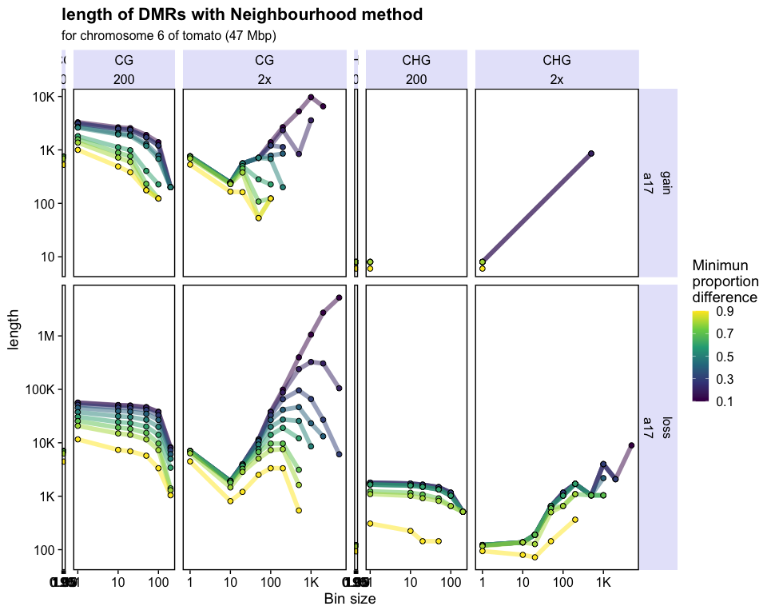

### by minimun proportion difference

For Bin sizes bigger than 20 bp, the length covered by DMRs decreases exponentially with the increase in minimum proportion difference.

#### number

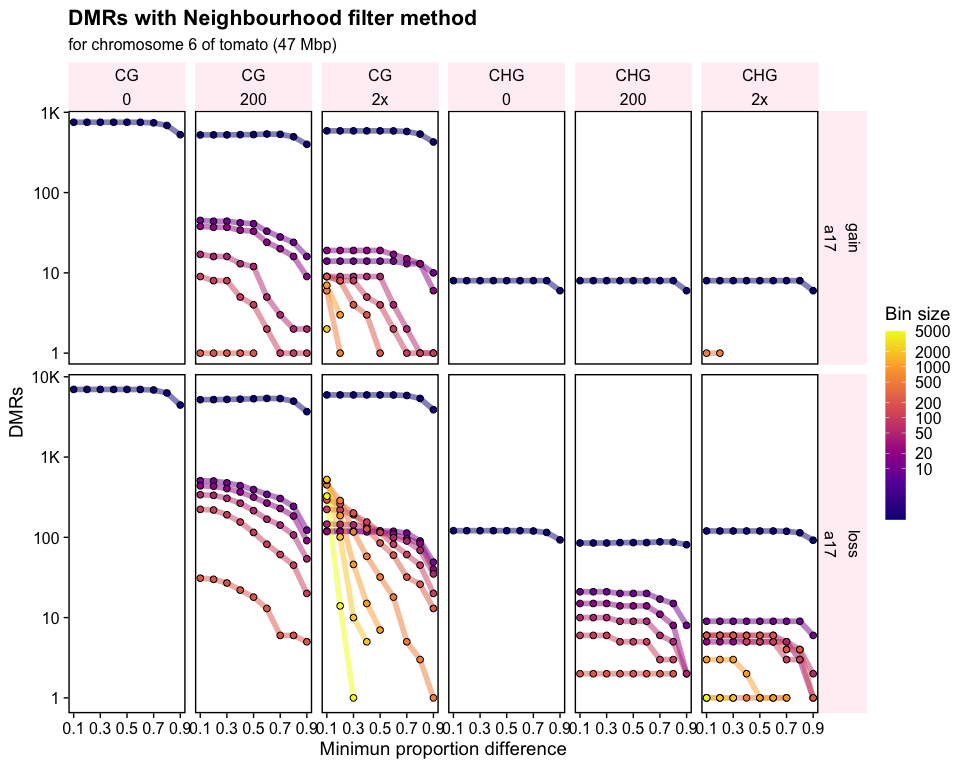

#### length

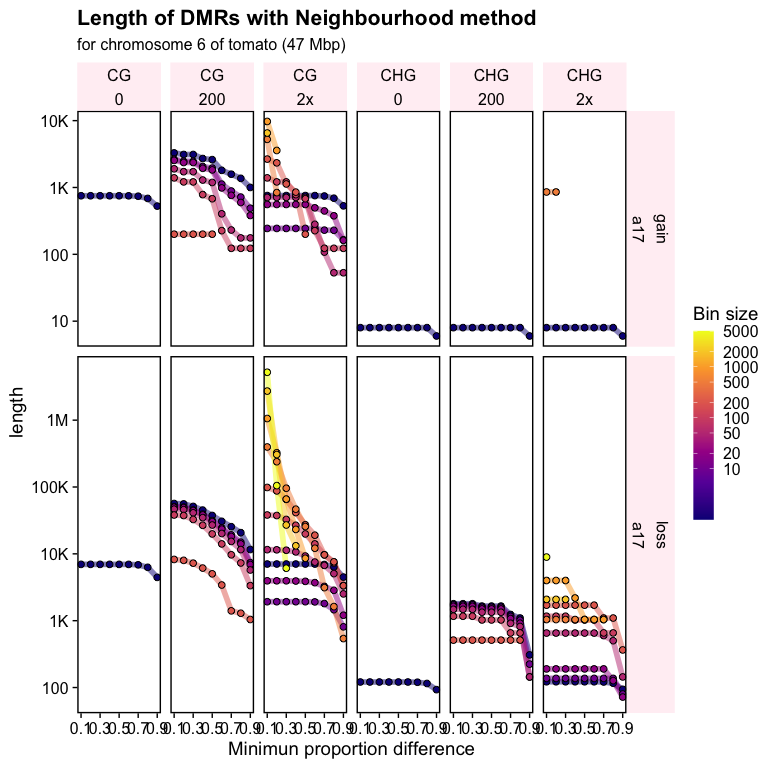

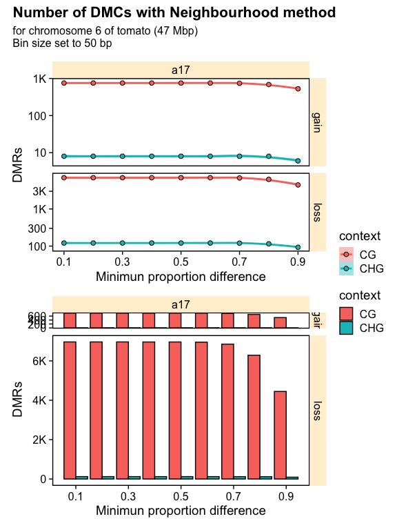

### Volcano plot

#### DMCs (1 bp & g = 0), mpd = 0.1

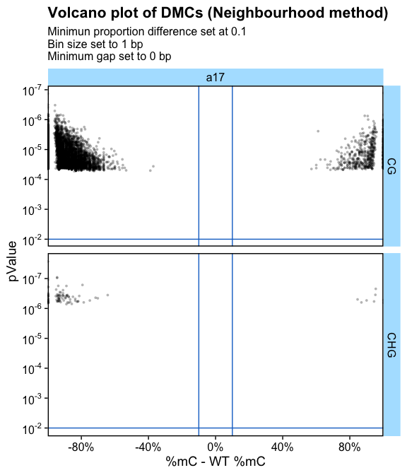

#### 50 bp, mpd = 0.3

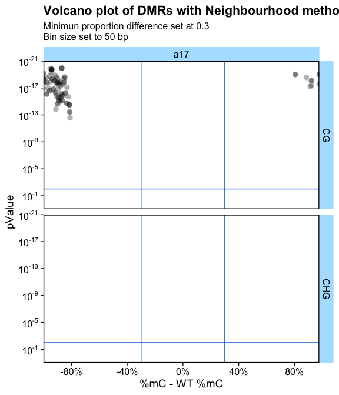

### colplot

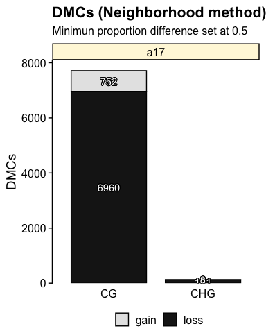

# 3. Final decisions

I will pool replicas.

For CG and CHG context I will use:

- noise filter method
- window size = 100 bp
- minimun proportion difference = 0.5

For CHH I will use:

- bins method
- window size = 50 bp
- minimun proportion difference = 0.3

## 3.1 rerun DMRs for ch06 with selected parameters

### Colplot

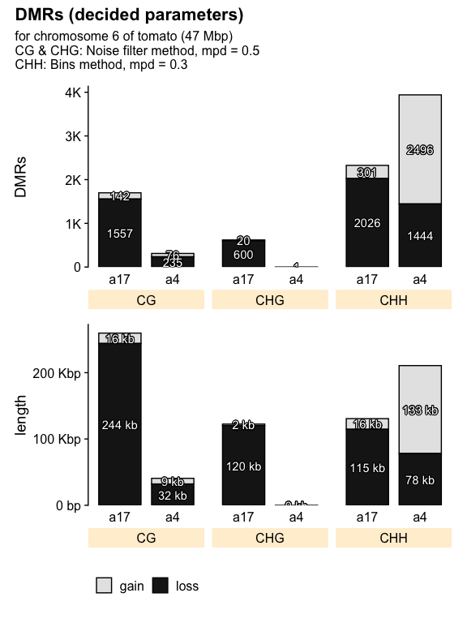

### Volcano

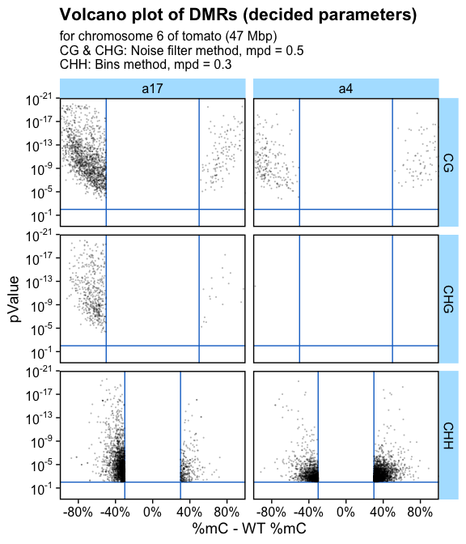

## 3.2 extract DMRs from the already computed DMRs

### Colplot

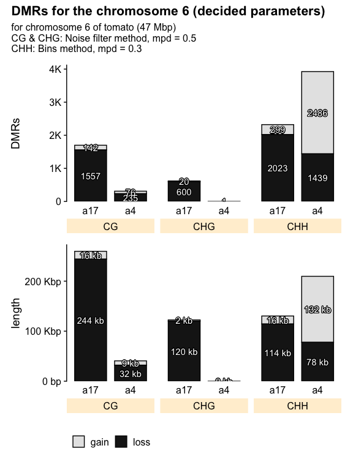

### Volcano

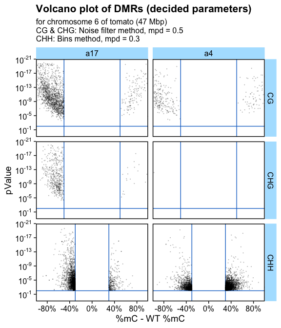

## 3.3 Expected numbers whole genome

Here I calculate the expected number of DMRs for the whole genome by multiplying the number of DMRs in ch06 by 17 times:

| sample | context | regionType | DMRs | length | DMRs_whole_genome | length_whole_genome |
| --- | --- | --- | --- | --- | --- | --- |
| a17 | CG | gain | 142 | 15620 | 2414 | 265540 |
| a17 | CG | loss | 1557 | 244086 | 26469 | 4149462 |
| a17 | CHG | gain | 20 | 2257 | 340 | 38369 |
| a17 | CHG | loss | 600 | 120226 | 10200 | 2043842 |
| a17 | CHH | gain | 301 | 16050 | 5117 | 272850 |
| a17 | CHH | loss | 2026 | 114650 | 34442 | 1949050 |
| a4 | CG | gain | 76 | 8586 | 1292 | 145962 |
| a4 | CG | loss | 235 | 32081 | 3995 | 545377 |
| a4 | CHG | loss | 1 | 60 | 17 | 1020 |
| a4 | CHH | gain | 2496 | 132600 | 42432 | 2254200 |

[output cut: 1 more lines]